# Report: Sample size planning for sequential ANOVAs

*created by the* [sprtt](https://meikesteinhilber.github.io/sprtt/) *package*  
Snijder-Steinhilber M, Schnuerch M, Schubert A (2025). *sprtt: Sequential Probability Ratio Tests Toolbox*. R package version 0.3.0,  
Source code of the simulation:

[figure not shown]

## Overview

This report provides practical guidance for planning studies using **sequential ANOVA** (SPRT), where the final sample size is not fixed in advance.

Unlike traditional sample size analyses, this report cannot predict the exact sample size needed to reach a decision in a specific study. Instead, it offers evidence-based recommendations derived from simulations, showing what sample sizes are typically required under various scenarios. Thus, these benchmarks enable realistic resource planning.

The actual final sample size in any study may differ substantially from the following recommendations due to sampling variability and departures from the assumed effect structure.

### Abbreviations

| Parameter | Description |
| --- | --- |
| $f_{\text{exp}}$ | Expected effect size (target effect) used for planning the sequential design |
| $f_{\text{true}}$ | True effect size in the simulated population |
| $\alpha$ | Type I error rate (probability of false positive) |
| $\beta$ | Type II error rate (probability of false negative) |
| $1-\beta$ | Target power. The desired probability of detecting a true effect. |
| $k$ | Number of groups |
| $N$ | Sample size |
| $N_{\text{max}}$ | The maximum sample size when the researcher stops collecting data independent of the test decision. This sample size is only reached in the worst-case scenario. |
| $N_{\text{mean}}$ | The average sample size at which a decision is reached across simulations. In a single study, the required sample size is expected to be close to this value. |

### Content

**Chapter I** illustrates the consequences of choosing a target effect size $f_{\text{exp}}$ across a range of possible true effects $f_{\text{true}}$. Although not specific to sequential designs, this perspective is essential for selecting a sensible expected effect size.

**Chapter II** presents the core planning results for a sequential study, focusing on two benchmark cases: the true effect equals the specified value ($f_{\text{true}} = f_{\text{exp}}$) and there is no true effect ($f_{\text{true}} = 0$).

**Chapter III** offers extended plots and tables to explore additional scenarios with more varied $f_{\text{true}}$ values.

### Technical details

The following results are based on a simulation with 10000 iterations per condition. Data were generated from a normal distribution, $\mathcal{N}(\mu,\sigma^2)$, under equal variances across groups and strictly balanced group sizes throughout data collection.

The analyses below use the following specifications:

- $f_{exp}$ = 0.25
- Power ($1-\beta$) = 0.95
- *k* groups = 3
- $\alpha$ = 0.05

## I. Influence of $f_{\text{exp}}$

For this report, the effect size was specified as $f_{\text{exp}} = 0.25$.

Choosing $f_{\text{exp}}$ is critical because it determines:

- which effect sizes can be detected with the target power and
- how much data are typically required to reach a decision.

It is recommended to set $f_{\text{exp}}$ to the **minimum effect of interest**: power declines quickly for effects smaller than $f_{\text{exp}}$, whereas choosing a much larger $f_{\text{exp}}$ may shorten data collection but risks missing practically relevant effects just below that value.

The plot below shows the power curve across possible true effects in the population, $f_{\text{true}}$.

The red color indicates that the power to detect a true effect of the corresponding size falls below the target power of 0.95, suggesting the design is underpowered for such effect sizes. The green color indicates that the power meets or exceeds the target power.

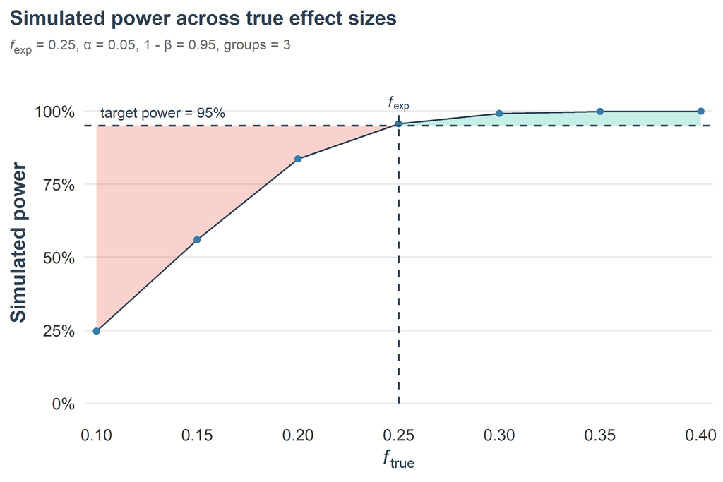

## II. Sample size recommendations

In the following plot you can see a visualization of the simulated samples, where either the effect in the data is as expected or the effect is zero. For a extended version of these results see **Chapter III**. The violin plot displays the variance of the sample sizes, to reach a final decision.

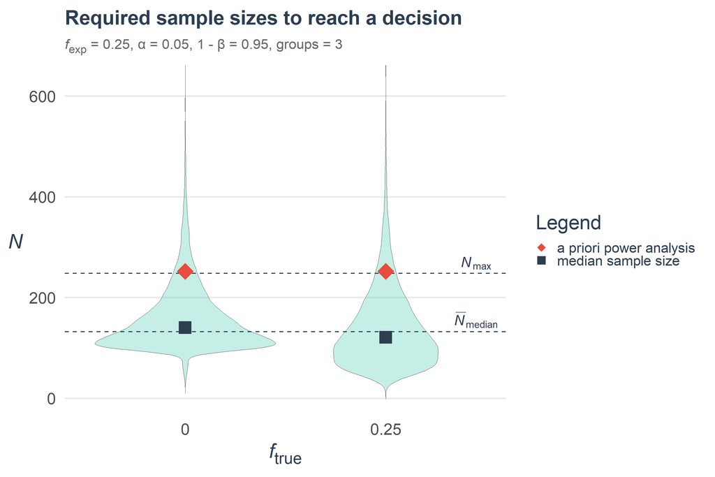

Extended numeric details are shown in the table below.

*Summary table*

*f*<sub>exp</sub> = 0.25, α = 0.05, 1 - β = 0.95, groups = 3

| *f*<sub>true</sub> | simulated power | Error rate % | Sample size (N) Mean | Sample size (N) Median<sup>1</sup> | Sample size (N) Min | Sample size (N) Max | *N* to reach decision rate (%) 75% | *N* to reach decision rate (%) 80% | *N* to reach decision rate (%) 85% | *N* to reach decision rate (%) 90%<sup>2</sup> | *N* to reach decision rate (%) 95% | Reference *N*: fixed design |  |
| --- | --- | --- | --- | --- | --- | --- | --- | --- | --- | --- | --- | --- | --- |
| 0 | - | 0.05 | 160 | 140 | 32 | 707 | 186 | 202 | 221 | 248 | 295 |  | 252 |
| 0.25 | 0.96 | 0.04 | 140 | 121 | 28 | 999 | 178 | 194 | 216 | 246 | 295 | 252 |  |

<sup>1</sup> grand median: *N̅*<sub>median</sub> = 132  
<sup>2</sup> recommended *N*<sub>max</sub> = 248

## III. Extended insights

### Plot: Sample size and varing $f_{\text{true}}$

This violin plot shows the distribution of required sample sizes $n$ across simulations for different assumed true effects $f_{\text{true}}$. Each violin summarizes how often a given $n$ occurred: wider sections indicate that sample sizes in that range were more frequent.

The violin colors indicate whether the test achieves the target power at each true effect.

- **Green** marks settings where $f_{\text{true}} \geq f_{\text{exp}}$ (or $f_{\text{true}} = 0$); at these settings the test reaches the target power $1-\beta$ = 0.95.
- **Red** marks settings where power falls short, so such effects would often not be detected with the specified power 0.95. If `f_expected = 0.1` is selected, no red violin is shown as it is outside of the simulated scope.

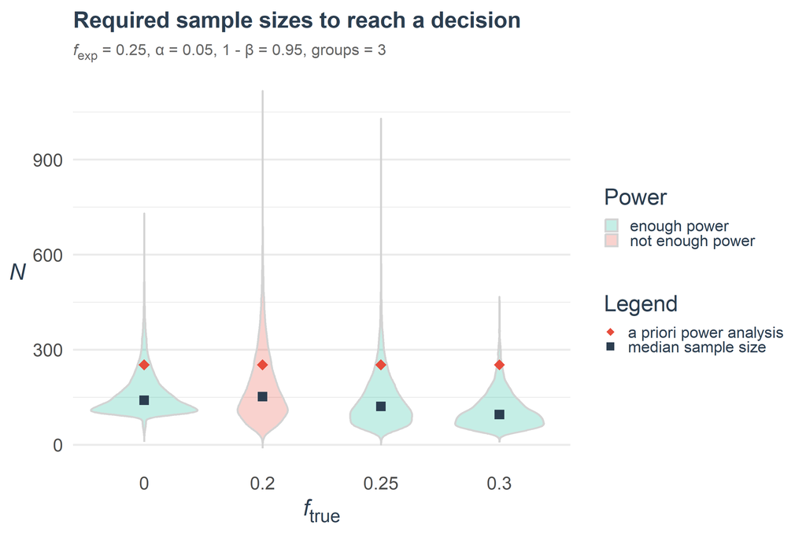

*Summary table*

*f*<sub>exp</sub> = 0.25, α = 0.05, 1 - β = 0.95, groups = 3

| *f*<sub>true</sub> | simulated power | Error rate % | Sample size (N) Mean | Sample size (N) Median | Sample size (N) Min | Sample size (N) Max | *N* to reach decision rate (%) 75% | *N* to reach decision rate (%) 80% | *N* to reach decision rate (%) 85% | *N* to reach decision rate (%) 90% | *N* to reach decision rate (%) 95% | Reference *N*: fixed design |  |
| --- | --- | --- | --- | --- | --- | --- | --- | --- | --- | --- | --- | --- | --- |
| 0 | - | 0.05 | 160 | 140 | 32 | 707 | 186 | 202 | 221 | 248 | 295 |  | 252 |
| 0.2 | 0.84 | 0.16 | 181 | 152 | 30 | 1075 | 232 | 258 | 286 | 328 | 397 | 252 |  |
| 0.25 | 0.96 | 0.04 | 140 | 121 | 28 | 999 | 178 | 194 | 216 | 246 | 295 | 252 |  |
| 0.3 | 0.99 | 0.01 | 109 | 95 | 28 | 445 | 135 | 147 | 162 | 182 | 218 | 252 |  |

### Plot: Sample size and varing $f_{\text{exp}}$

The next plot below visualizes the required sample sizes, when the true value is set and one uses different specification of $f_{\text{exp}}$. Here you can see how the specification of $f_{\text{exp}}$ influences the sample sizes also in direct comparison to a fixed sample plan. Sequential designs maintain efficiency despite underestimating $f_{\text{exp}}$, whereas fixed designs are locked into their initial specification – a key advantage demonstrated in this plot

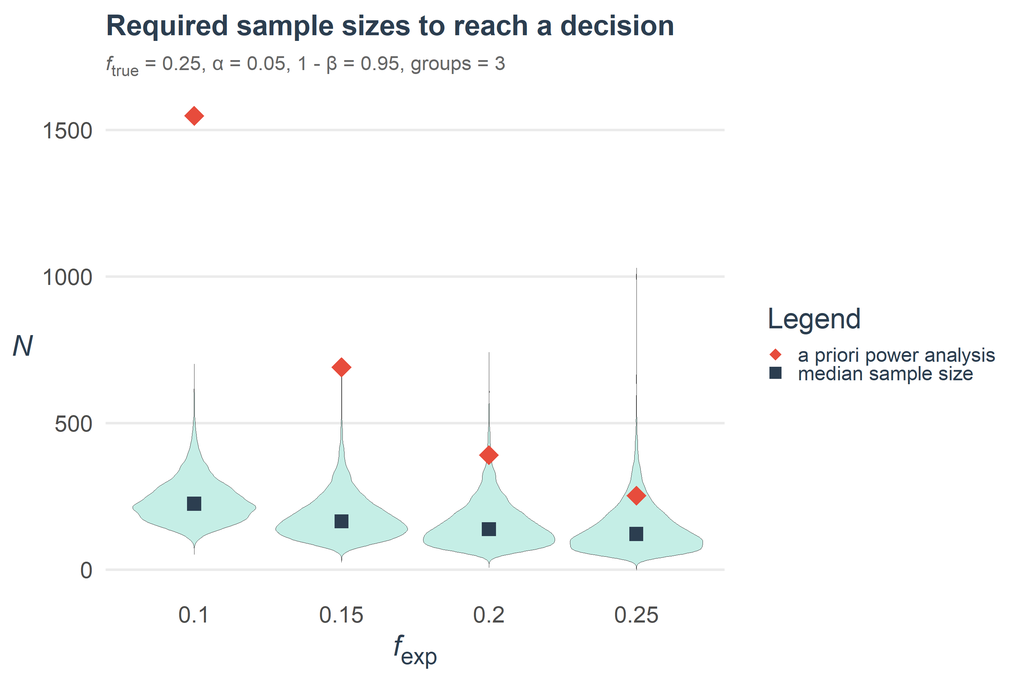

### Plot: Cumulative decisions

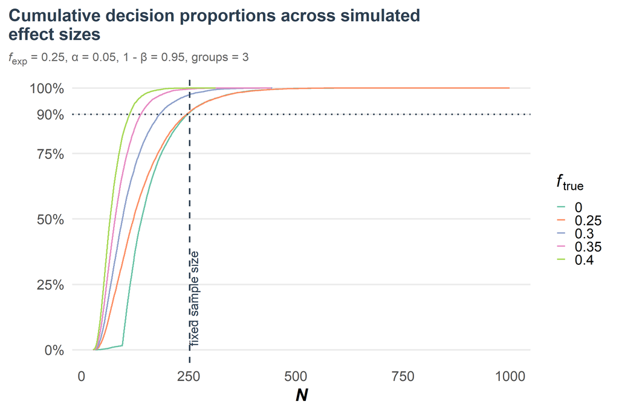